# Rapport Travail Pratique N°2

Emma BRAZ DA COSTA-RAMOS (BRAE21560400) Gautier BRÈRE (BRIG01040400) Edward CARAMANOS (CARE17080300) Mariama CIRÉ CAMARA (CAMM06609200) Yoann CORGNET (CORY14010400)

2025-04-22

## I- Introduction

Ce travail pratique est la suite du travail réalisé pendant la première moité de ce trimestre.

Dans un premier temps, nous allons formuler plusieurs hypothèses statistiques à tester sur les données issues du fichier “movies.csv” du site TMDB. Les analyses porteront principalement sur les variables budget, revenue, runtime, popularity, vote_average, vote_count, original_language, et genres.

Puis nous testerons d’autres modèles afin de prédire le revenu des films, en comparant ces résultats aux régressions linéaires faites dans le TP1.

*Objectif 1* : Explorer et valider des relations statistiques entre différentes caractéristiques des films, afin de mieux comprendre les facteurs de succès cinématographique.

*Objectif 2* : Rechercher un modèle de donnée performant pour prédire le revenu d’un film.

## II- Importation et nettoyage des données

Ce dataset contient les métadonnées de plus de 700 000 films répertoriés dans l’ensemble de données TMDB. Il est mis à jour quotidiennement pour garantir la mise à jour de l’ensemble de données sur les films. Les points de données comprennent les acteurs, l’équipe, les mots-clés de l’intrigue, le budget, les revenus, les affiches, les dates de sortie, les langues, les sociétés de production, les pays, le nombre de votes TMDB et les moyennes des votes, les critiques, les recommandations.

**Description des variables**

- id : Identifiant unique pour chaque film.
- title : Titre du film.
- genres : Genres du film, combinés dans une seule chaîne de caractères (ex : Action-Comedy).
- original_language : Langue originale du film.
- overview : Résumé ou description du film.
- popularity : Score de popularité du film.
- production_companies : Compagnies de production associées au film, listées dans une chaîne de caractères.
- release_date : Date de sortie du film.
- budget : Budget du film en dollars.
- revenue : Revenu généré par le film en dollars.
- runtime : Durée du film en minutes.
- status : Statut du film (ex : Released).
- tagline : Slogan du film.
- vote_average : Moyenne des votes pour le film.
- vote_count : Nombre total de votes reçus par le film.
- credits : Principaux acteurs et membres de l’équipe du film.
- keywords : Mots-clés associés au film, listés dans une chaîne de caractères.
- poster_path : Chemin vers l’image de l’affiche du film.
- backdrop_path : Chemin vers l’image de fond du film.
- recommendations : Identifiants de films recommandés basés sur ce film, listés dans une chaîne de caractères.

### A- Importation des données

```r
movies <- read.csv("data/movies.csv")
```

Le dataset compte 722317 entrées pour 20 variables.

### B- Supression des variables non pertinentes

Voici le résumé des variables du dataset:

```r
skim(movies)
```

Data summary

| Name | movies |
| --- | --- |
| Number of rows | 722317 |
| Number of columns | 20 |
| _______________________ |  |
| Column type frequency: |  |
| character | 13 |
| numeric | 7 |
| ________________________ |  |
| Group variables | None |

**Variable type: character**

| skim_variable | n_missing | complete_rate | min | max | empty | n_unique | whitespace |
| --- | --- | --- | --- | --- | --- | --- | --- |
| title | 0 | 1 | 0 | 234 | 4 | 575321 | 0 |
| genres | 0 | 1 | 0 | 129 | 210317 | 11050 | 0 |
| original_language | 0 | 1 | 2 | 2 | 0 | 167 | 0 |
| overview | 0 | 1 | 0 | 999 | 118243 | 541884 | 6 |
| production_companies | 0 | 1 | 0 | 679 | 384926 | 147600 | 0 |
| release_date | 0 | 1 | 0 | 10 | 51549 | 41474 | 0 |
| status | 0 | 1 | 7 | 15 | 0 | 6 | 0 |
| tagline | 0 | 1 | 0 | 284 | 613841 | 95910 | 4 |
| credits | 0 | 1 | 0 | 7172 | 224714 | 423217 | 0 |
| keywords | 0 | 1 | 0 | 1258 | 511678 | 119803 | 0 |
| poster_path | 0 | 1 | 0 | 32 | 184493 | 483219 | 0 |
| backdrop_path | 0 | 1 | 0 | 32 | 499106 | 197370 | 0 |
| recommendations | 0 | 1 | 0 | 156 | 686301 | 32104 | 0 |

**Variable type: numeric**

| skim_variable | n_missing | complete_rate | mean | sd | p0 | p25 | p50 | p75 | p100 | hist |
| --- | --- | --- | --- | --- | --- | --- | --- | --- | --- | --- |
| id | 0 | 1.00 | 526920.12 | 253200.15 | 2 | 328914.0 | 533351.0 | 737872.0 | 968161 | ▃▇▇▇▇ |
| popularity | 0 | 1.00 | 1.92 | 23.69 | 0 | 0.6 | 0.6 | 1.3 | 8764 | ▇▁▁▁▁ |
| budget | 0 | 1.00 | 404345.28 | 8242867.85 | 0 | 0.0 | 0.0 | 0.0 | 5000000000 | ▇▁▁▁▁ |
| revenue | 0 | 1.00 | 1007747.33 | 20483206.23 | -12 | 0.0 | 0.0 | 0.0 | 2920357254 | ▇▁▁▁▁ |
| runtime | 34335 | 0.95 | 199.09 | 85842.57 | 0 | 5.0 | 50.0 | 90.0 | 50505050 | ▇▁▁▁▁ |
| vote_average | 0 | 1.00 | 2.45 | 3.18 | 0 | 0.0 | 0.0 | 5.6 | 10 | ▇▁▂▂▁ |
| vote_count | 0 | 1.00 | 28.48 | 396.58 | 0 | 0.0 | 0.0 | 2.0 | 34857 | ▇▁▁▁▁ |

Pour notre analyse et pour réduire la taille du dataset, nous supprimerons les variables que nous n’utiliserons pas pour notre analyse :

```r
clean_movies <- select(movies, -id, -overview, -tagline, -credits, -keywords, -poster_path, -backdrop_path, -recommendations)
head(clean_movies)
```

```
##                              title                           genres
## 1                Meg 2: The Trench    Action-Science Fiction-Horror
## 2              The Pope's Exorcist          Horror-Mystery-Thriller
## 3             Deadpool & Wolverine    Action-Comedy-Science Fiction
## 4 Transformers: Rise of the Beasts Action-Adventure-Science Fiction
## 5                   Dune: Part Two        Science Fiction-Adventure
## 6            Venom: The Last Dance Science Fiction-Action-Adventure
##   original_language popularity
## 1                en   8763.998
## 2                en   5953.227
## 3                en   5410.496
## 4                en   5409.104
## 5                en   4742.163
## 6                en   4674.885
##                                                                                                             production_companies
## 1 Apelles Entertainment-Warner Bros. Pictures-di Bonaventura Pictures-CMC Pictures-Gravity Pictures-China Film Group Corporation
## 2                                         Screen Gems-2.0 Entertainment-Jesus & Mary-Worldwide Katz-Loyola Productions-FFILME.RO
## 3             Marvel Studios-Maximum Effort-21 Laps Entertainment-20th Century Studios-Kevin Feige Productions-TSG Entertainment
## 4            Skydance-Paramount-di Bonaventura Pictures-Bay Films-New Republic Pictures-Tom DeSanto/Don Murphy Production-Hasbro
## 5                                                                                                             Legendary Pictures
## 6                         Columbia Pictures-Pascal Pictures-Matt Tolmach Productions-Hutch Parker Entertainment-Arad Productions
##   release_date   budget    revenue runtime   status vote_average vote_count
## 1   2023-08-02 1.29e+08  352056482     116 Released        7.079       1365
## 2   2023-04-05 1.80e+07   65675816     103 Released        7.433        545
## 3   2024-07-24 2.00e+08 1326387384     128 Released        7.765       3749
## 4   2023-06-06 2.00e+08  407045464     127 Released        7.340       1007
## 5   2024-02-27 1.90e+08  683813734     167 Released        8.300       2770
## 6   2024-10-22 1.20e+08  310000000     109 Released        6.522        603
```

### C- Nettoyage des variables

- **Variable `release_date` :**

Regardons la distribution des dates de sorties :

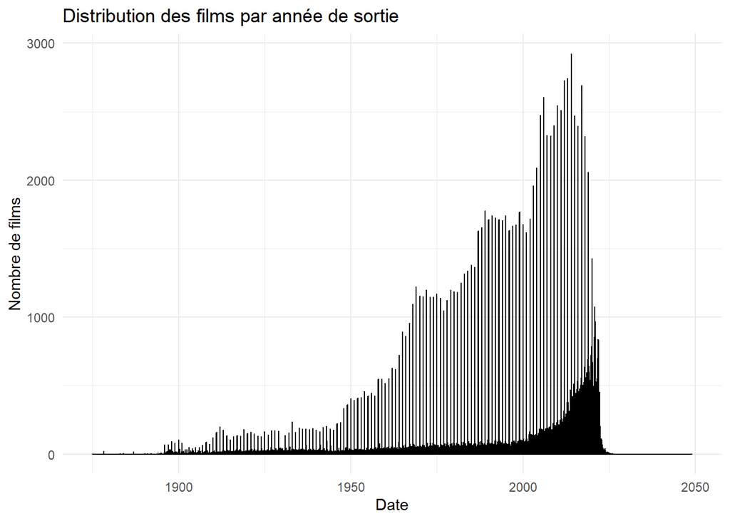

```r
clean_movies$release_date <- as.Date(clean_movies$release_date, format="%Y-%m-%d")

ggplot(clean_movies, aes(x = release_date)) +
  geom_histogram(binwidth = 5, fill="steelblue", color="black") +
  labs(title="Distribution des films par année de sortie", x="Date", y="Nombre de films") +
  theme_minimal()
```

On peut observer deux choses :  
1- Les films ont tendance à sortir à des dates précises durant l’année, nous nous retrouvons donc avec des pics.  
Pour notre analyse, nous regarderons donc l’année, le mois et la décennie de sortie, et non la date exacte:

```r
# Suppression des dates maquantes
clean_movies <- clean_movies %>% filter(!is.na(release_date))
# Ajout des variables
clean_movies <- clean_movies %>%
  mutate(
    release_year = as.numeric(format(release_date, "%Y")),
    release_mounth = as.numeric(format(release_date, "%m")),
    release_decate = as.numeric(format(release_date, "%Y")) %/% 10 * 10
  )

head(clean_movies %>% select(title, release_date, release_year, release_mounth, release_decate))
```

```
##                              title release_date release_year release_mounth
## 1                Meg 2: The Trench   2023-08-02         2023              8
## 2              The Pope's Exorcist   2023-04-05         2023              4
## 3             Deadpool & Wolverine   2024-07-24         2024              7
## 4 Transformers: Rise of the Beasts   2023-06-06         2023              6
## 5                   Dune: Part Two   2024-02-27         2024              2
## 6            Venom: The Last Dance   2024-10-22         2024             10
##   release_decate
## 1           2020
## 2           2020
## 3           2020
## 4           2020
## 5           2020
## 6           2020
```

2- Nous observons que certains films sont sortis après 2025, regardons desquels il s’agit :

```r
clean_movies %>% filter(release_date > "2025-01-22") %>% select(title, status, release_date) %>% head()
```

```
##                                       title          status release_date
## 1 Mission: Impossible - The Final Reckoning Post Production   2025-05-21
## 2                         A Minecraft Movie Post Production   2025-04-02
## 3                            Fast X: Part 2         Planned   2025-04-04
## 4           The Fantastic Four: First Steps   In Production   2025-07-23
## 5                                  Avatar 4   In Production   2026-12-16
## 6                                  Avatar 5   In Production   2028-12-20
```

Ce sont donc des films qui ne sont pas encore sortis et dont la date est une prévision.  
Pour notre analyse, nous nous concentrerons uniquement sur les films sortis:

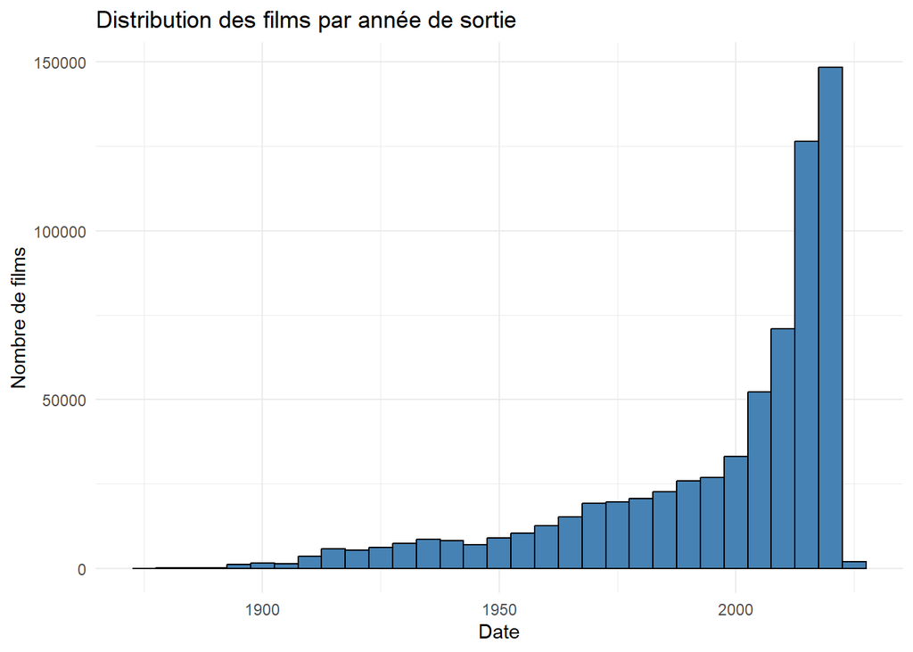

```r
clean_movies <- clean_movies %>% filter(status == "Released")

ggplot(clean_movies, aes(x = release_year)) +
  geom_histogram(binwidth = 5, fill="steelblue", color="black") +
  labs(title="Distribution des films par année de sortie", x="Date", y="Nombre de films") +
  theme_minimal()
```

- **Variable `runtime` :**

Après une observation des durées de films, nous remarquons plusieurs choses intéressantes :

```r
clean_movies %>%
  filter(!is.na(runtime)) %>%
  arrange(desc(runtime)) %>%
  head(10) %>%
  select(title, runtime)
```

```
##                         title runtime
## 1                   Logistics   51420
## 2                    Ambiancé   43200
## 3        Modern Times Forever   14400
## 4  Svalbard minutt for minutt   13319
## 5                   Cinématon   12480
## 6                   Cinématon   12480
## 7                Beijing 2003    9000
## 8     Untitled #125 (Hickory)    7200
## 9                 Matrjoschka    5700
## 10               #ALLMYMOVIES    4320
```

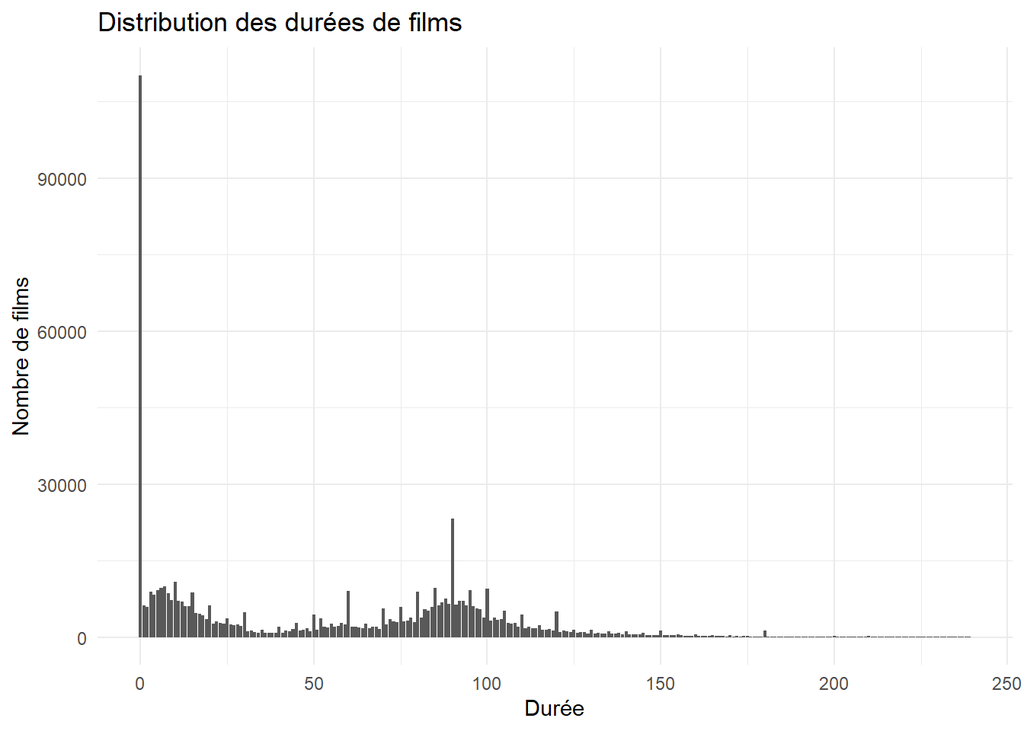

```r
clean_movies = clean_movies %>%
  filter(runtime < 240) # Limitons-nous à des films de moins de 4h

ggplot(clean_movies, aes(runtime)) +
  geom_bar() +
  labs(title="Distribution des durées de films", x="Durée", y="Nombre de films") +
  theme_minimal()
```

L’histogramme de la durée des films de moins de 4h nous permet d’obtenir plusieurs informations :  
1. On observe une distinction entre les courts métrages (10 min en moyenne) et les longs métrages (1h30 en moyenne).  
2. Il existe beaucoup de films dont la durée est de zéro: 110196 au total (soit 17.21 %).

Afin de ne pas biaiser nos modèles sur des valeurs manquantes/nulles, nous ne tiendrons pas compte des films dont la durée n’est pas renseignée:

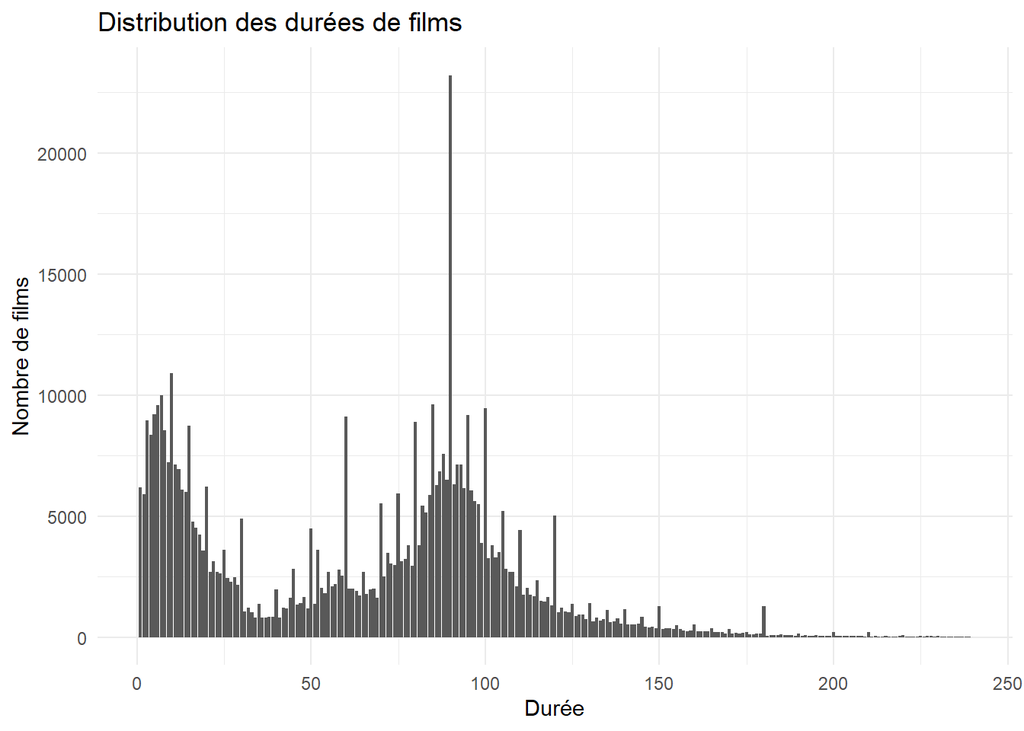

```r
clean_movies <- clean_movies %>% filter(!is.na(runtime) & runtime > 0)

ggplot(clean_movies, aes(runtime)) +
  geom_bar() +
  labs(title="Distribution des durées de films", x="Durée", y="Nombre de films") +
  theme_minimal()
```

- **Variable `genres` :**

Le genre des films est stocké sous la forme “genre_principale[-genre_secondaire]…”, ce qui fait que nous nous retrouvons avec un total de 11050 genres.

Nous allons séparer ces genres, puis compter le nombre de films par genre.

```r
clean_movies <- clean_movies %>%
  mutate(genres = gsub("-.*", "", genres))

head(clean_movies%>% select(title,genres))
```

```
##                              title          genres
## 1                Meg 2: The Trench          Action
## 2              The Pope's Exorcist          Horror
## 3             Deadpool & Wolverine          Action
## 4 Transformers: Rise of the Beasts          Action
## 5                   Dune: Part Two Science Fiction
## 6            Venom: The Last Dance Science Fiction
```

Nous nous retrouvons donc avec 20 genres.

Top 3 des genres principaux :

```r
clean_movies %>%
  filter(!is.na(genres) & genres != "") %>%
  count(genres) %>%
  arrange(desc(n)) %>%
  head(n = 3)
```

```
##        genres      n
## 1       Drama 103049
## 2 Documentary  86947
## 3      Comedy  61441
```

- **Variables `vote_count` et `vote_average` :**

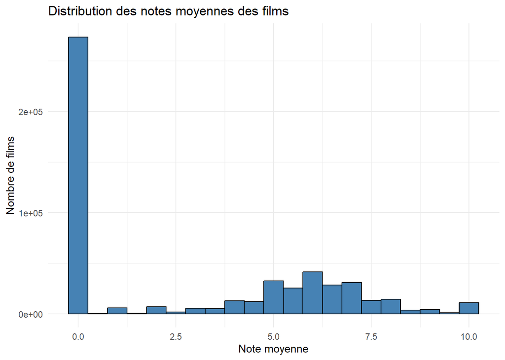

```r
ggplot(clean_movies, aes(x = vote_average)) +
  geom_histogram(binwidth = 0.5, fill="steelblue", color="black") +
  labs(
    title = "Distribution des notes moyennes des films",
     x = "Note moyenne",
     y = "Nombre de films"
  ) +
  theme_minimal()
```

Nous observons que beaucoup de notes sont à zéro, cela peut être dû à deux choses :  
1- La note du film est de 0  
2- Le nombre de votes est de zéro, la moyenne est donc automatiquement à zéro. Cela représente 273364 films sur les 273689 qui ont une note de zéro, soit 99.88 %.

Nous ne tiendrons donc pas compte de ces films :

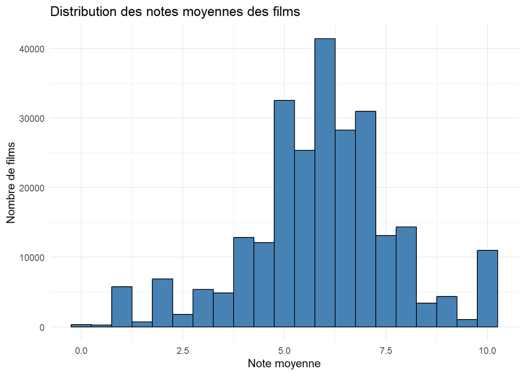

```r
clean_movies = clean_movies %>% filter(vote_count != 0)

ggplot(clean_movies, aes(x = vote_average)) +
  geom_histogram(binwidth = 0.5, fill="steelblue", color="black") +
  labs(
    title = "Distribution des notes moyennes des films",
     x = "Note moyenne",
     y = "Nombre de films"
  ) +
  theme_minimal()
```

- **Variable `revenue` :**

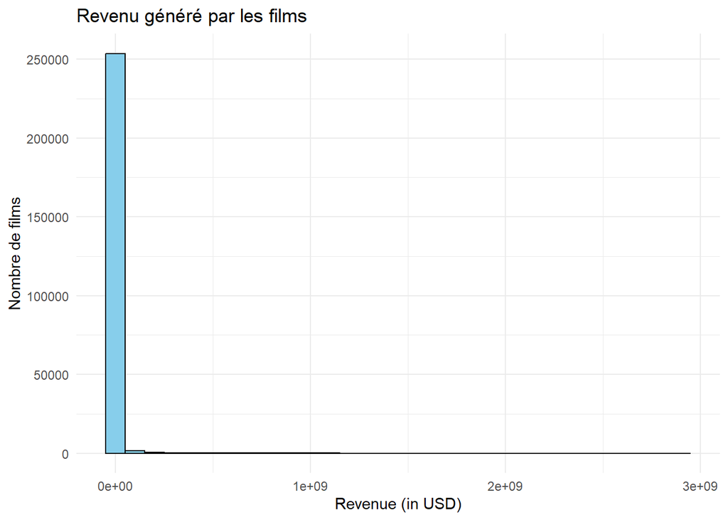

```r
ggplot(clean_movies, aes(revenue)) +
  geom_histogram(binwidth = 100000000, fill = "skyblue", color = "black") +  # Adjust binwidth as needed
  labs(title = "Revenu généré par les films",
       x = "Revenue (in USD)",
       y = "Nombre de films") +
  theme_minimal()
```

On remarque 94.09 % des films on un revenue de 0, donc non référencé. Supprimons donc ces films.

```r
clean_movies <- clean_movies %>% filter(revenue != 0)
```

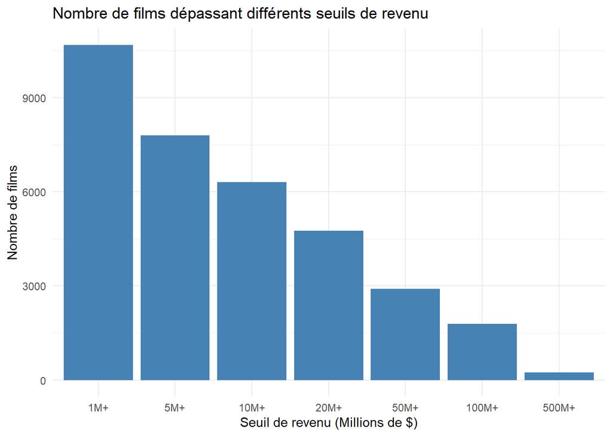

```r
# Définissons 7 seuils de revenu en millions pour avoir une idées de combien de film peuvent atteindre combien de revenue
revenue_thresholds <- c(1, 5, 10, 20, 50, 100, 500) # En millions

# Dataframe pour quantité de film dépassant chaque seuils
revenue_counts <- data.frame(
  Seuil = factor(paste0(revenue_thresholds, "M+"), levels = paste0(revenue_thresholds, "M+")),  # Formater les labels pour affichage graphique
  Nombre_de_films = sapply(revenue_thresholds * 1e6, function(threshold) sum(clean_movies$revenue > threshold, na.rm = TRUE))
)

ggplot(revenue_counts, aes(x = Seuil, y = Nombre_de_films)) +
  geom_bar(stat="identity", fill="steelblue") +
  labs(title="Nombre de films dépassant différents seuils de revenu",
       x="Seuil de revenu (Millions de $)",
       y="Nombre de films") +
  theme_minimal()
```

### D- Rééchantillonnage

Après nettoyage, nous nous retrouvons avec un un dataset de 15164 films.  
Et voici le résumé des variables du dataset après nettoyage :

```r
skim(clean_movies)
```

Data summary

| Name | clean_movies |
| --- | --- |
| Number of rows | 15164 |
| Number of columns | 15 |
| _______________________ |  |
| Column type frequency: |  |
| character | 5 |
| Date | 1 |
| numeric | 9 |
| ________________________ |  |
| Group variables | None |

**Variable type: character**

| skim_variable | n_missing | complete_rate | min | max | empty | n_unique | whitespace |
| --- | --- | --- | --- | --- | --- | --- | --- |
| title | 0 | 1 | 1 | 104 | 0 | 14164 | 0 |
| genres | 0 | 1 | 0 | 15 | 88 | 20 | 0 |
| original_language | 0 | 1 | 2 | 2 | 0 | 77 | 0 |
| production_companies | 0 | 1 | 0 | 679 | 814 | 11498 | 0 |
| status | 0 | 1 | 8 | 8 | 0 | 1 | 0 |

**Variable type: Date**

| skim_variable | n_missing | complete_rate | min | max | median | n_unique |
| --- | --- | --- | --- | --- | --- | --- |
| release_date | 0 | 1 | 1914-04-10 | 2024-10-22 | 2008-10-24 | 7662 |

**Variable type: numeric**

| skim_variable | n_missing | complete_rate | mean | sd | p0 | p25 | p50 | p75 | p100 | hist |
| --- | --- | --- | --- | --- | --- | --- | --- | --- | --- | --- |
| popularity | 0 | 1 | 23.06 | 151.67 | 0.09 | 4.07 | 9.75 | 1.8050e+01 | 8764 | ▇▁▁▁▁ |
| budget | 0 | 1 | 15727504.02 | 33106426.42 | 0.00 | 0.00 | 1892978.00 | 1.6000e+07 | 460000000 | ▇▁▁▁▁ |
| revenue | 0 | 1 | 47163347.37 | 131828631.00 | -12.00 | 577641.00 | 5596487.50 | 3.2000e+07 | 2920357254 | ▇▁▁▁▁ |
| runtime | 0 | 1 | 105.31 | 24.99 | 1.00 | 92.00 | 102.00 | 1.1700e+02 | 239 | ▁▅▇▁▁ |
| vote_average | 0 | 1 | 6.40 | 1.18 | 0.00 | 5.80 | 6.40 | 7.0900e+00 | 10 | ▁▁▅▇▁ |
| vote_count | 0 | 1 | 1048.94 | 2505.20 | 1.00 | 28.00 | 182.00 | 8.4625e+02 | 34857 | ▇▁▁▁▁ |
| release_year | 0 | 1 | 2003.18 | 17.44 | 1914.00 | 1996.00 | 2008.00 | 2.0160e+03 | 2024 | ▁▁▁▃▇ |
| release_mounth | 0 | 1 | 6.81 | 3.43 | 1.00 | 4.00 | 7.00 | 1.0000e+01 | 12 | ▆▅▅▆▇ |
| release_decate | 0 | 1 | 1998.54 | 17.60 | 1910.00 | 1990.00 | 2000.00 | 2.0100e+03 | 2020 | ▁▁▁▂▇ |

Pour terminer, nous répartissons notre jeu de données entre l’entraînement et les tests, avec une proportion de 80% :

```r
train_test_split <- initial_split(clean_movies, prop = 0.8)

train_movies <- training(train_test_split)
test_movies <- testing(train_test_split)
```

## III- Hypothèses statistiques

### A- Hypthèse 1: Films en anglais et revenu

- H0 : Les films en anglais ne génèrent pas plus de revenus que les films dans d’autres langues.
- H1 : Les films en anglais génèrent plus de revenus.

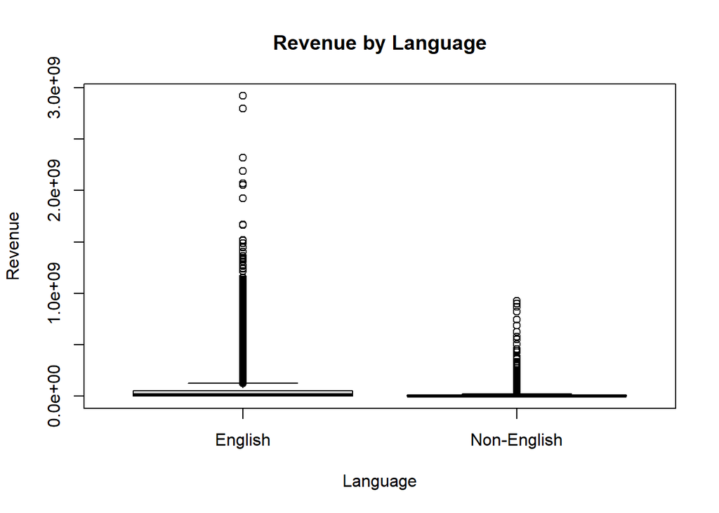

```r
# Groupons d'abord les langues de films en deux catégories: films anglais et non-anglais

clean_movies$english_film <- ifelse(clean_movies$original_language == "en", "English", "Non-English")

# Visualisation des films en anglais

boxplot(revenue ~ english_film, data = clean_movies, main = "Revenue by Language", ylab = "Revenue", xlab = "Language")
```

nous allons maintenant apppliquer lest-t à nos deux groupes de films

```r
# Appliquons un test t pour deux groupes
t_test_result <- t.test(revenue ~ english_film, data = clean_movies, alternative = "greater")

# Afficher le résultat du test
print(t_test_result)
```

```
##
##  Welch Two Sample t-test
##
## data:  revenue by english_film
## t = 29.654, df = 13856, p-value < 2.2e-16
## alternative hypothesis: true difference in means between group English and group Non-English is greater than 0
## 95 percent confidence interval:
##  46217772      Inf
## sample estimates:
##     mean in group English mean in group Non-English
##                  62468343                  13536242
```

D’après ce test, p-value< 2.2e-16 (extrêmement petite) donc on rejette l’hypothèse nulle (H0). L’alternative hypothesis nous confirme que “le revenu moyen des films en anglais est supérieur à celui des films non-anglais” avec une intervalle de confiance de 95%. Nous conclurons que les films anglophones génèrent significativement plus de revenus que les autres.

### B- Hypthèse 2: Regroupement naturel des films basé sur `budget`, `revenue`, `popularity`

- H0 : Il n’existe aucun regroupement naturel des films basé sur budget, revenue, popularity.
- H1 : Il existe des clusters naturels de films.

```r
# selection des variables qui nous interressent

movies_cluster <- clean_movies[, c("budget", "revenue", "popularity")]

# Standardisation

movies_scaled <- scale(movies_cluster)
```

Nous allons utiliser la methode de coude pour déterminer le nombre de cluster

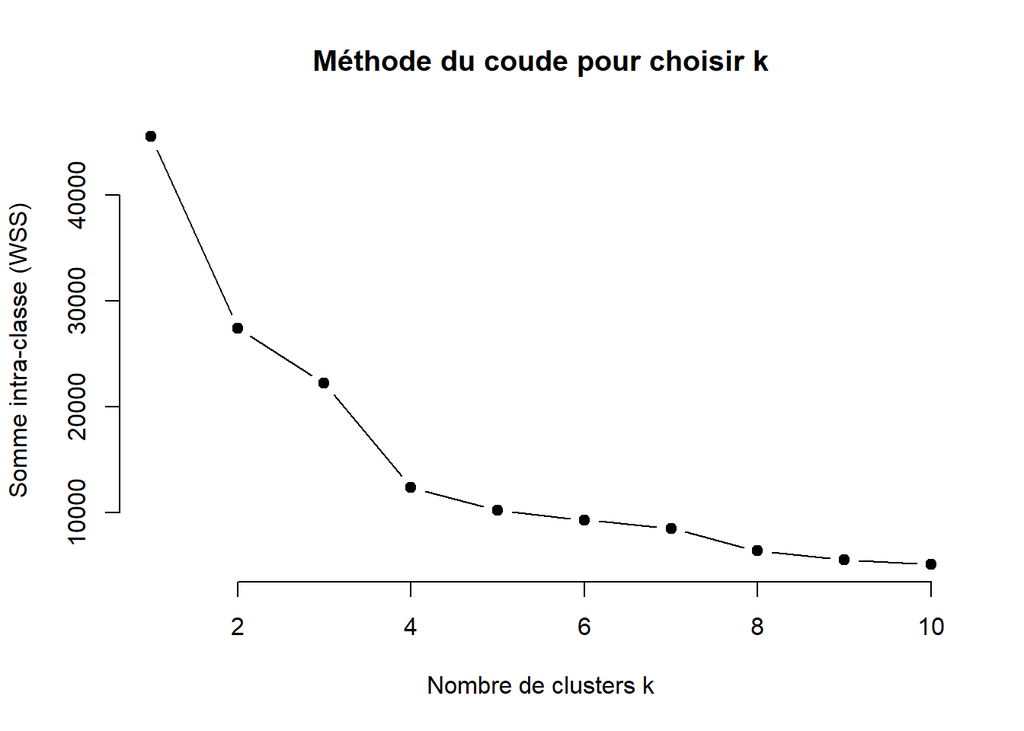

```r
wss <- numeric(10)
for (k in 1:10) {
  kmeans_model <- kmeans(movies_scaled, centers = k, nstart = 10)
  wss[k] <- kmeans_model$tot.withinss
}

# Tracer la méthode du coude
plot(1:10, wss, type = "b", pch = 19, frame = FALSE,
     xlab = "Nombre de clusters k",
     ylab = "Somme intra-classe (WSS)",
     main = "Méthode du coude pour choisir k")
```

Ici le “coude” se situe à k = 4, ce qui suggère que 4 clusters sont naturels pour regrouper les films selon budget, revenue et popularity.

```r
# Pour k = 4 clusters

set.seed(123)
kmeans_final <- kmeans(movies_scaled, centers = 4, nstart = 25)

# Affichage de la répartition des films dans chaque cluster

table(kmeans_final$cluster)
```

```
##
##     1     2     3     4
##    13   282  1586 13283
```

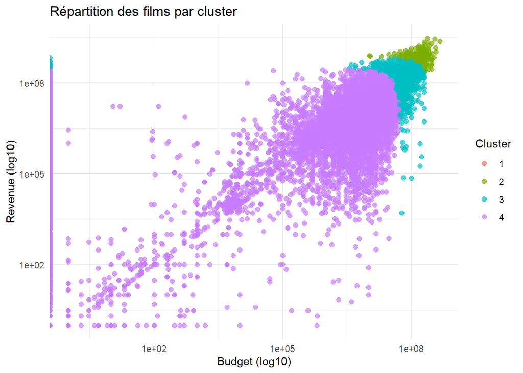

```r
movies_cluster$cluster <- as.factor(kmeans_final$cluster)

# nous allons visualiser les clusters en utilisant deux variables : budget vs revenue
ggplot(movies_cluster, aes(x = budget, y = revenue, color = cluster)) +
  geom_point(alpha = 0.7, size = 2) +
  scale_x_log10() + scale_y_log10() +
  labs(title = "Répartition des films par cluster",
       x = "Budget (log10)",
       y = "Revenue (log10)",
       color = "Cluster") +
  theme_minimal()
```

Dans cette representation nous voyons principalement les clusters 2,3,4.

- Le cluster 4 contient la majorité des films, principalement des films à faible et moyenne budjet et revenu.
- Les clusters 2 et 3 contiennent des films à budget et revenu élévé , mais en nombre beaucoup plus faible.
- Le cluster 1 ne contient pas assez de films (13) ce qui fait qu’il n’est pas visible dans le graphe.

*En conclusion*, nous rejetons l’hypothèse nulle H0 et acceptons l’hypothèse H1, car la méthode du coude (k = 4) et la visualisation des clusters indiquent clairement l’existence de regroupements naturels parmi les films basés sur leur budget, leur revenu et leur popularité.

### C- Hypthèse 3: Popularité et rentabilité

Hypothèses :

H0 : La rentabilité dépend uniquement de la popularité du film.

H1 : La rentabilité dépend davantage d’autres facteurs que de la seule popularité.

```r
library(tidyverse)
library(randomForest)

df <- clean_movies %>%
  filter(revenue > 0, budget > 0) %>%
  mutate(rentabilite = revenue / budget) %>%
  select(rentabilite, budget, popularity, runtime, vote_average, vote_count) %>%
  na.omit()

set.seed(42)
model_rf_rent <- randomForest(rentabilite ~ ., data = df, importance = TRUE)

# importance(model_rf_rent)
```

Le budget est le facteur le plus influent sur le revenu.

La popularité a un impact modéré, moins important que le budget et le vote count.

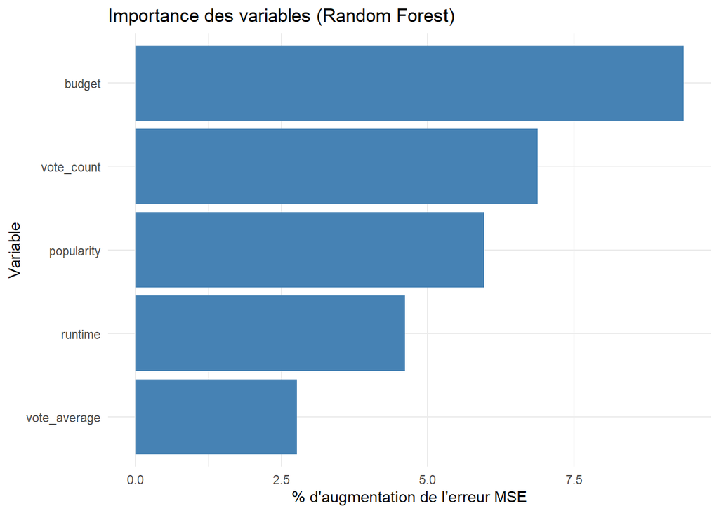

```r
imp <- as.data.frame(importance(model_rf_rent))
imp$Variable <- rownames(imp)

ggplot(imp, aes(x = reorder(Variable, `%IncMSE`), y = `%IncMSE`)) +
  geom_col(fill = "steelblue") +
  coord_flip() +
  labs(
    title = "Importance des variables (Random Forest)",
    x = "Variable",
    y = "% d'augmentation de l'erreur MSE"
  ) +
  theme_minimal()
```

L’analyse des importances des variables montre que la popularité n’est pas le facteur principal pour prédire le revenu ; des variables comme le budget et le nombre de votes sont plus déterminantes. Cela rejette H0 et confirme H1 : la rentabilité ne dépend pas uniquement de la popularité.

Hypothèses : H0 : La durée d’un film (runtime) n’a pas d’effet significatif sur sa popularité.

H1 : La durée d’un film (runtime) a un effet significatif sur sa popularité.

[figure not shown]

```r
imp <- as.data.frame(importance(model_rf_rent))
imp$Variable <- rownames(imp)

ggplot(imp, aes(x = reorder(Variable, `%IncMSE`), y = `%IncMSE`)) +
  geom_col(fill = "steelblue") +
  coord_flip() +
  labs(
    title = "Importance des variables (Random Forest)",
    x = "Variable",
    y = "% d'augmentation de l'erreur MSE"
  ) +
  theme_minimal()
```

## IV- Modèles de prédiction de la rentabilité

### A- Analyse en composante principale

```r
# Sélection des variables numériques pertinentes et suppression des NA

acp_data <- clean_movies %>%

select(budget, revenue, popularity, runtime, vote_average, vote_count) %>%

drop_na()

# standardisation des données

acp_scaled <- scale(acp_data)

# application de l’ACP

res_pca <- prcomp(acp_scaled, center = TRUE, scale. = TRUE)

# affichage de la variance expliquée

summary(res_pca)
```

```
## Importance of components:
##                           PC1    PC2    PC3    PC4     PC5     PC6
## Standard deviation     1.6064 0.9955 0.9760 0.9575 0.59780 0.44906
## Proportion of Variance 0.4301 0.1652 0.1588 0.1528 0.05956 0.03361
## Cumulative Proportion  0.4301 0.5953 0.7540 0.9068 0.96639 1.00000
```

Les résultats montrent que la première composante principale (PC1) explique environ 43 % de la variance totale, et que les deux premières composantes combinées (PC1 + PC2) en expliquent environ 60 %.

Cela signifie qu’on peut résumer l’essentiel de l’information présente dans les 6 variables d’origine sur seulement deux dimensions, ce qui est utile pour la visualisation et l’exploration.

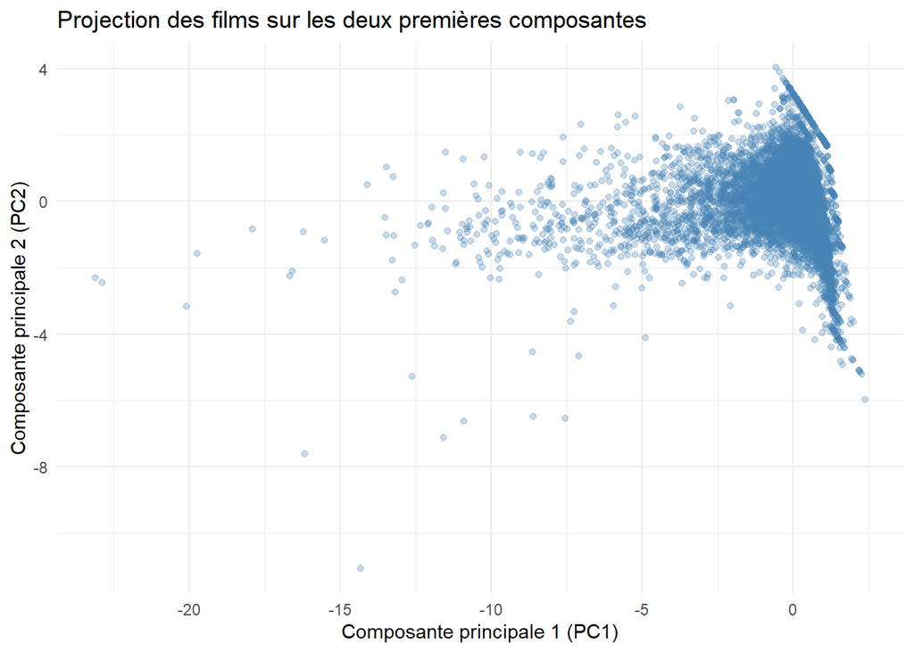

```r
pca_df <- as.data.frame(res_pca$x)

ggplot(pca_df, aes(x = PC1, y = PC2)) +

geom_point(alpha = 0.3, color = "steelblue") +

labs(title = "Projection des films sur les deux premières composantes",

x = "Composante principale 1 (PC1)",

y = "Composante principale 2 (PC2)") +

theme_minimal()
```

Ce graphique montre la projection des films sur les deux premières composantes principales.

On observe une forme en “nuage” dense qui révèle une grande concentration de films aux caractéristiques similaires (ex. budget et revenu modérés), ainsi que des films plus éloignés (très hauts budgets ou revenus) qui apparaissent sur les bords.

Cela permet d’identifier visuellement des groupes de films similaires selon leurs caractéristiques numériques principales.

### B- Modèle polynomial

```r
# modèle polynomial de degré 2 :

poly_model <- lm(revenue ~ poly(budget, 2), data = train_movies)

# résumé du modèle

summary(poly_model)
```

```
##
## Call:
## lm(formula = revenue ~ poly(budget, 2), data = train_movies)
##
## Residuals:
##        Min         1Q     Median         3Q        Max
## -898041519  -12081136   -6557479     202764 2085460966
##
## Coefficients:
##                   Estimate Std. Error t value Pr(>|t|)
## (Intercept)      4.806e+07  7.973e+05   60.28   <2e-16 ***
## poly(budget, 2)1 1.124e+10  8.781e+07  127.99   <2e-16 ***
## poly(budget, 2)2 1.929e+09  8.781e+07   21.96   <2e-16 ***
## ---
## Signif. codes:  0 '***' 0.001 '**' 0.01 '*' 0.05 '.' 0.1 ' ' 1
##
## Residual standard error: 87810000 on 12128 degrees of freedom
## Multiple R-squared:  0.5817, Adjusted R-squared:  0.5816
## F-statistic:  8432 on 2 and 12128 DF,  p-value: < 2.2e-16
```

Le modèle polynomial de degré 2 est significatif (p-value < 2e-16) pour l’ensemble.

Les deux coefficients du polynôme sont également significatifs.

```r
test_movies <- test_movies %>%

mutate(pred_poly_revenue = predict(poly_model, newdata = test_movies))
```

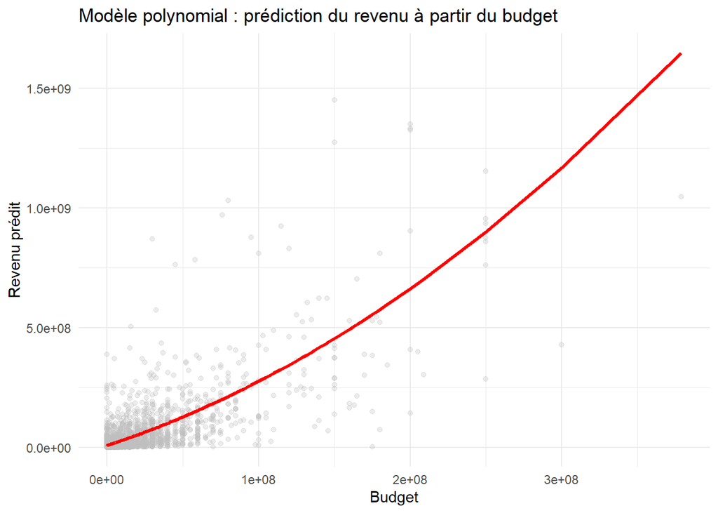

```r
ggplot(test_movies, aes(x = budget, y = revenue)) +

geom_point(alpha = 0.3, color = "grey") +

geom_line(aes(y = pred_poly_revenue), color = "red", size = 1.2) +

labs(title = "Modèle polynomial : prédiction du revenu à partir du budget",

x = "Budget",

y = "Revenu prédit") +

theme_minimal()
```

La courbe rouge montre l’ajustement du modèle polynomial sur les données de test.

On observe une relation croissante et courbée : les films à gros budget génèrent en moyenne plus de revenus, mais la relation n’est pas strictement proportionnelle.

Ce modèle permet donc de mieux capter la réalité du phénomène qu’une droite simple.

### C- Modèle d’Arbre et RandomForest

#### 1. Variables pour les modèles:

```r
rentability_group <- function(revenue, budget) {
  if (revenue > 10 * budget) {
    return("HIGH")  # Très rentable
  } else if (revenue > budget) {
    return("MEDIUM")  # Moyen
  } else {
    return("LOSS")  # Non rentable
  }
}

tree_train_movies <- train_movies %>%
  mutate(
    rentability = factor(mapply(rentability_group, revenue, budget)),
    log_budget = log(budget + 1),
    log_vote_count = log(vote_count + 1)
  )

tree_test_movies <- test_movies %>%
  mutate(
    rentability = factor(mapply(rentability_group, revenue, budget)),
    log_budget = log(budget + 1),
    log_vote_count = log(vote_count + 1)
  )

tree_train_movies %>% count(rentability)
```

```
##   rentability    n
## 1        HIGH 4913
## 2        LOSS 2697
## 3      MEDIUM 4521
```

#### 2. Entraînement d’un Arbre avec Cross Validation:

```r
library(tree)
tree.movies <- tree(
  rentability ~ . - revenue,
  tree_train_movies
)
summary(tree.movies)
```

```
##
## Classification tree:
## tree(formula = rentability ~ . - revenue, data = tree_train_movies)
## Variables actually used in tree construction:
## [1] "budget"     "vote_count"
## Number of terminal nodes:  5
## Residual mean deviance:  1.009 = 12240 / 12130
## Misclassification error rate: 0.2574 = 3122 / 12131
```

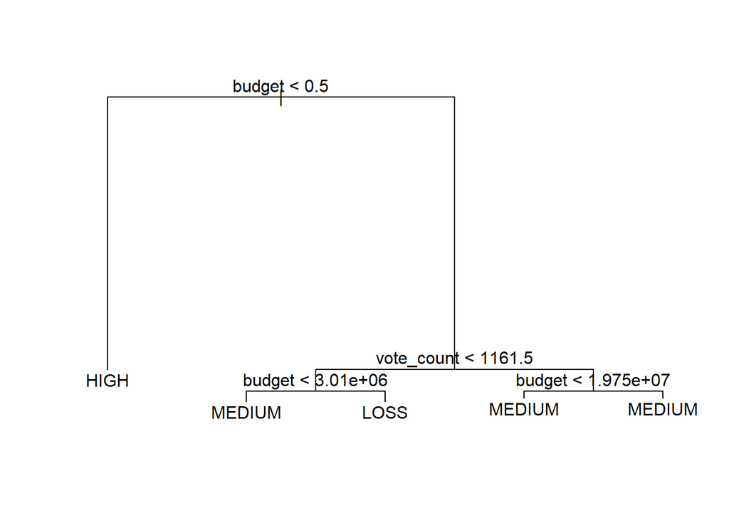

```r
plot(tree.movies)
text(tree.movies, pretty = 0)
```

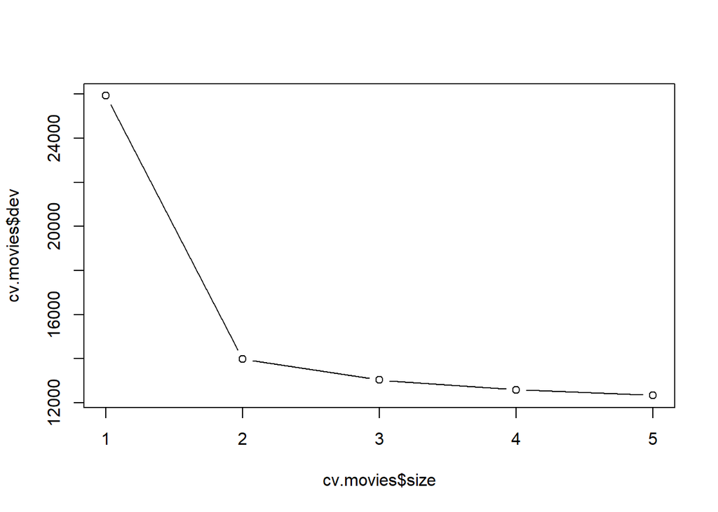

```r
cv.movies <- cv.tree(tree.movies)
plot(cv.movies$size, cv.movies$dev, type = "b")
```

```r
tree.pred <- predict(tree.movies, tree_test_movies, type = "class")
confusion_matrix <- table(tree.pred, tree_test_movies$rentability)
tree_accuracy <- sum(diag(confusion_matrix)) / sum(confusion_matrix)
confusion_matrix
```

```
##
## tree.pred HIGH LOSS MEDIUM
##    HIGH   1035    0      0
##    LOSS     19  427    411
##    MEDIUM  132  236    773
```

Nous avons donc une précision finale de 73.69 % pour ce modèle.

#### 3. Amélioration avec RandomForest :

```r
library(randomForest)
set.seed(1)

forest.movie <- randomForest(rentability ~ . - revenue, data = tree_train_movies, importance = TRUE)
forest.movie
```

```
##
## Call:
##  randomForest(formula = rentability ~ . - revenue, data = tree_train_movies,      importance = TRUE)
##                Type of random forest: classification
##                      Number of trees: 500
## No. of variables tried at each split: 4
##
##         OOB estimate of  error rate: 18%
## Confusion matrix:
##        HIGH LOSS MEDIUM class.error
## HIGH   4457   66    390  0.09281498
## LOSS     22 1739    936  0.35520949
## MEDIUM  102  668   3751  0.17031630
```

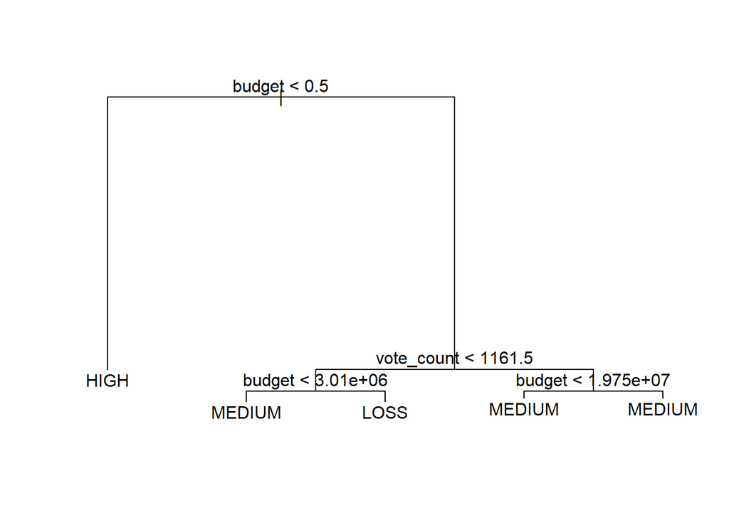

```r
plot(tree.movies)
text(tree.movies, pretty = 0)
```

**Calcule des performances :**

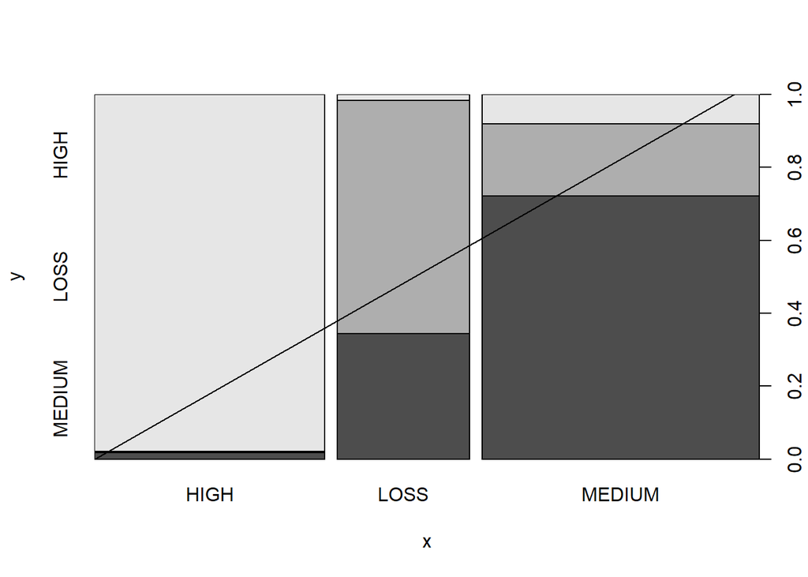

```r
forest.pred <- predict(forest.movie, newdata = tree_test_movies)
plot(forest.pred, tree_test_movies$rentability)
abline(0, 1)
```

```r
forest_accuracy <- sum(forest.pred == tree_test_movies$rentability) / length(tree_test_movies$rentability)
```

Nous avons donc une précision finale de 79.76 % pour ce modèle. Soit une augmentation de 6.07 %.